# A Homework of Biblical Proportions

Ivory Poo

## Group Member:

1. Karen Chik
2. Ivory Poo
3. Selina Prasetyo
4. Ariel Sanders

In this HW, we will analyze the text of the bible. The ascii version resides in the file “ascii_bible.txt” on Camino. Use an editor to familiarize yourself with the structure of the file. Then perform the following operations, listed below as questions for you to answer.

## Q1: Read in the file using any R function you like and store each verse in a text array. After which print the top 20 verses. (Remove the top two lines which contain the title.)

```r
setwd("~/Desktop/Machine Learning")
library(stringr)
bible<-readLines("data_files/ascii_bible.txt")
bible <- gsub( "        ", " ", bible)
bible <- Filter(function(x) !any(grepl("Book ", x)), bible)
bible <- paste(bible, collapse = "")
bible <- unlist(strsplit(gsub("([[:digit:]]{3}:[[:digit:]]{3})", "~\\1", bible), "~"))
text <- bible[bible!= ""]
```

## Q2: How many verses are there in total?

Answer: There are 31102 verses.

```r
length(text)
```

```
## [1] 31102
```

## Q3: Each verse has the number “CCC:VVV” where CCC is the chapter number and VVV is the verse number. How many chapters are there?

Answer: They are 1189 chapters.

```r
number=substr(text, 1,7)
temp1=strsplit(number, ":")
df<-matrix(unlist(temp1), ncol = 2, byrow = TRUE)
df<-as.data.frame(df)
sum(df$V2=="001")
```

```
## [1] 1189
```

## Q4: Extract an array for the verse numbers, and also one for the verse text.

```r
verse_text=substr(text, 9,str_length(text))
verse_number=df$V2
```

## Q5: Lower case all text.

```r
verse_text_lower=tolower(verse_text)
```

## Q6: Convert the text of all verses into a Corpus using the **tm** package.

```r
library(tm)
text_corpus_lower = Corpus(VectorSource(verse_text_lower))
```

## Q7: Remove all punctuation. Use a corpus function for this. How many unique words are there in the bible?

Answer: They are 12651 unique words.

```r
text_corpus_nopunc = tm_map(text_corpus_lower,removePunctuation)
#text_corpus[[2]]$content
tdm_nopunc = TermDocumentMatrix(text_corpus_nopunc,control=list(minWordLength=1))
```

## Q8: Remove all stopwords. Now how many unique terms are there?

Answer: They are 12555 unique words.

```r
text_corpus_nostops=tm_map(text_corpus_nopunc,removeWords,stopwords("english"))
tdm_nostops = TermDocumentMatrix(text_corpus_nostops,control=list(minWordLength=1))
print(lapply(text_corpus_nostops, as.character)[10:15])
```

```
## $`10`
## [1] " god called  dry land earth   gathering together   waters called  seas  god saw    good"
##
## $`11`
## [1] " god said let  earth bring forth grass  herb yielding seed   fruit tree yielding fruit   kind whose seed    upon  earth    "
##
## $`12`
## [1] "  earth brought forth grass  herb yielding seed   kind   tree yielding fruit whose seed      kind  god saw    good"
##
## $`13`
## [1] "  evening   morning   third day"
##
## $`14`
## [1] " god said let   lights   firmament   heaven  divide  day   night  let    signs   seasons   days  years"
##
## $`15`
## [1] " let    lights   firmament   heaven  give light upon  earth    "
```

## Q9: Now stem the text, to remove multiplicity of similar words of the same root.

```r
#stemDocument
text_corpus_stem = tm_map(text_corpus_nostops,stemDocument)
#print(lapply(text_corpus_stem, as.character)[10:15])
```

## Q10: How many distinct words are there in the bible, after stemming?

```r
tdm_stem = TermDocumentMatrix(text_corpus_stem,control=list(minWordLength=1))
tdm_stem
```

```
## <<TermDocumentMatrix (terms: 9120, documents: 31102)>>
## Non-/sparse entries: 332732/283317508
## Sparsity           : 100%
## Maximal term length: 18
## Weighting          : term frequency (tf)
```

## Q11: Convert the TDM into a matrix and find the 50 most common words in the bible.

```r
tdm_stem_matrix = as.matrix(tdm_stem)
tdm_stem_wordcount = sort(rowSums(tdm_stem_matrix),decreasing=TRUE)
tdm_stem_names = names(tdm_stem_wordcount)
tdm_stem_names[1:50]
```

```
##  [1] "shall"    "unto"     "lord"     "thou"     "god"      "thi"
##  [7] "said"     "will"     "thee"     "son"      "king"     "upon"
## [13] "man"      "day"      "israel"   "say"      "hath"     "hous"
## [19] "peopl"    "came"     "come"     "one"      "hand"     "children"
## [25] "also"     "land"     "thing"    "men"      "father"   "shalt"
## [31] "let"      "even"     "made"     "went"     "offer"    "now"
## [37] "behold"   "citi"     "saith"    "word"     "therefor" "everi"
## [43] "hast"     "name"     "make"     "great"    "david"    "may"
## [49] "pass"     "earth"
```

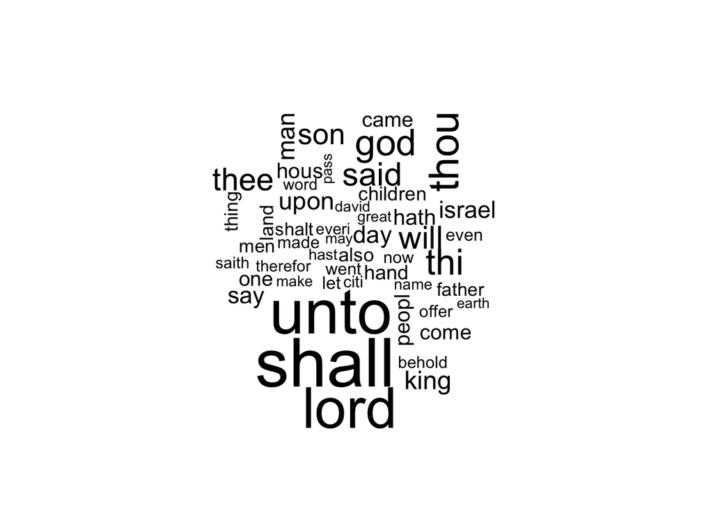

```r
library(wordcloud)
wordcloud(tdm_stem_names[1:50],tdm_stem_wordcount[1:50])
```

## Q13: Mood score the original text of the bible (before stemming)

```r
HIDict = readLines("data_files/inqdict.txt")
dict_pos = HIDict[grep("Pos",HIDict)]
poswords = NULL
for (s in dict_pos) {
    s = strsplit(s,"#")[[1]][1]
    poswords = c(poswords,strsplit(s," ")[[1]][1])
}
dict_neg = HIDict[grep("Neg",HIDict)]
negwords = NULL
for (s in dict_neg) {
    s = strsplit(s,"#")[[1]][1]
    negwords = c(negwords,strsplit(s," ")[[1]][1])
}
poswords = tolower(poswords)
negwords = tolower(negwords)

text = NULL
for (j in 1:length(text_corpus_nopunc)) {
            temp = text_corpus_nopunc[[j]]$content
            if (temp!="") { text = c(text,temp) }}
text = as.array(text)
text = paste(text,collapse="\n")
text = str_replace_all(text, "[\r\n]" , " ")
text = strsplit(unlist(text)," ")

posmatch = match(text,poswords)
numposmatch = length(posmatch[which(posmatch>0)])
negmatch = match(text,negwords)
numnegmatch = length(negmatch[which(negmatch>0)])
print(c(numposmatch,numnegmatch))
```

```
## [1] 0 0
```

## Q14: Summarize the bible into less than 500 verses. (Or some fraction of the total number of verses, it’s your choice.) Be super careful here as this may take a long time unless you are clever about it, or find some elegant way to speed things up!

```r
text_summary = function(text, n) {
  m = length(text)  # No of sentences in input
  jaccard = matrix(0,m,m)  #Store match index
  for (i in 1:m) {
    for (j in i:m) {
      a = text[i]; aa = unlist(strsplit(a," "))
      b = text[j]; bb = unlist(strsplit(b," "))
      jaccard[i,j] = length(intersect(aa,bb))/
                          length(union(aa,bb))
      jaccard[j,i] = jaccard[i,j]
    }
  }
  similarity_score = rowSums(jaccard)
  res = sort(similarity_score, index.return=TRUE,
          decreasing=TRUE)
  idx = res$ix[1:n]
  summary = text[idx]
}
#Split the verse text into 200 lists evenly, 156 lines each list

n <- length(verse_text)
k <- n/200
split_verse_text<-split(verse_text, rep(1:ceiling(n/k), each=round(k)+1)[1:n])
#Summarize each list into 25 lines
res=list()
for (i in (1:length(split_verse_text))){
  res[[i]] = text_summary(split_verse_text[[i]],25)
}

#Combine the first summary 200X25=500 lines into one list then split it again evenly into 20 list, with 25 lines in each list

res_combined=unlist(res)
n <- length(res_combined)#length(verse_text)
k <- n/20 ## your LEN
split_res_combined<-split(res_combined, rep(1:ceiling(n/k), each=round(k))[1:n])
#Summarize each list into 24 lines, so the final result will have 480 verses
res1=list()
for (i in (1:length(split_res_combined))){
  res1[[i]] = text_summary(split_res_combined[[i]],24)
}
final_summary=unlist(res1)

head(final_summary,3)
```

```
## [1] "And the thing was good in the eyes of Pharaoh, and in the eyes of all his servants."
## [2] "And the LORD was with Joseph, and he was a prosperous man; and he was in the house of his master the Egyptian."
## [3] "And Israel took his journey with all that he had, and came to Beersheba, and offered sacrifices unto the God of his father Isaac."
```

## Q15: Find the main 3 topics in the bible, and the top 25 words in each topic. Can you find an interpretation of each topic?

```r
library(text2vec)
library(magrittr)
library(tm)
stopw = stopwords('en')
stopw = c(stopw,"also","shall","us","thee","let","o","shalt","therefore","will","may", "thou","thy", "ye","may","every","even", "s", "unto", "said","saying","thus", "upon","hath")
head(verse_text_lower)
```

```
## [1] "in the beginning god created the heaven and the earth."
## [2] "and the earth was without form, and void; and darkness was upon the face of the deep. and the spirit of god moved upon the face of the waters."
## [3] "and god said, let there be light: and there was light."
## [4] "and god saw the light, that it was good: and god divided the light from the darkness."
## [5] "and god called the light day, and the darkness he called night. and the evening and the morning were the first day."
## [6] "and god said, let there be a firmament in the midst of the waters, and let it divide the waters from the waters."
```

```r
tokens = verse_text_lower %>% word_tokenizer()
it = itoken(tokens)
v = create_vocabulary(it, stopwords = stopw) %>% prune_vocabulary(term_count_min=5)
vectrzr = vocab_vectorizer(v, grow_dtm = TRUE, skip_grams_window = 5)
dtm = create_dtm(it, vectrzr)
print(dim(dtm))
```

```
## [1] 31102  5137
```

```r
#Do LDA
lda = LatentDirichletAllocation$new(n_topics=3, v)
lda$fit(dtm,n_iter = 25)
doc_topics = lda$fit_transform(dtm,n_iter = 25)
print(dim(doc_topics))
```

```
## [1] 31102     3
```

```r
#Get word vectors by topic
topic_wv = lda$get_word_vectors()
print(dim(topic_wv))
```

```
## [1] 5137    3
```

```r
library(LDAvis)
lda$plot()
```

[output not shown]